# Repaso breve de inferencia bayesiana

*Ejemplo*: Sea $\mathbf{y}=\left(y_1\ldots,y_n\right)$ una m.a. de una distribución gamma con parámetros $\boldsymbol{\theta}=\left(\theta_1,\theta_2\right)^{\prime}$ y función de densidad

$$ f(x\mid\theta_1,\theta_2)=\frac{\theta_2^{\theta_1}}{\Gamma(\theta_1)}y^{\theta_1-1}e^{\theta_2y} $$

Suponer *a priori* que $\theta_1$ y $\theta_2$ son independientes con distribuciones propias gamma; esto es,

$$ \pi(\boldsymbol{\theta})=\mathrm{Ga}(\theta_1\mid a,b)\mathrm{Ga}(\theta_2\mid c,d). $$

La función de verosimilitud es

\begin{eqnarray} L(\boldsymbol{\theta}\mid \mathbf{y})=\prod_{i=1}^n f(y_i\mid\theta_1,\theta_2)&\propto&\exp\left\{\theta_1\sum_{i=1}^n \ln y_i-\theta_2\sum_{i=1}^n y_i+n\ln\left(\frac{\theta_2^{\theta_1}}{\Gamma(\theta_1)}\right)\right\}\\ &=&\exp\left\{t^{\prime}(\mathbf{y})\boldsymbol{\theta}-nb(\boldsymbol{\theta})\right\} \end{eqnarray}

donde $t^{\prime}(\mathbf{y})=\left(\sum_{i=1}^n \ln y_i,-\sum_{i=1}^n y_i\right)^{\prime}$ es el vector de estadísticos suficientes y $b(\boldsymbol{\theta})=\ln \Gamma(\theta_1)-\theta_1\ln \theta_2$. El EMV $\hat{\boldsymbol{\theta}}$ es la solución de

$$ \frac{\partial}{\partial\boldsymbol{\theta}}\ln L(\boldsymbol{\theta}\mid \mathbf{y})\vert_{\boldsymbol{\theta}=\hat{\boldsymbol{\theta}}}=\mathbf{0}; $$

esto es,

\begin{eqnarray} \sum_{i=1}^n \ln y_i-n\psi^{\prime}(\hat\theta_1)+n\ln\hat\theta_2&=&0\\ -\sum_{i=1}^n y_i+n\hat\theta_1/\hat\theta_2=0. \end{eqnarray}

Donde $\frac{d}{d\theta_1}\ln\Gamma(\theta_1)=\psi^{\prime}(\theta_1)$ es la función digamma. De la segunda ecuación $\hat\theta_2=\hat\theta_1/\bar{y}$ y $\hat\theta_1$ se obtiene resolviendo

$$ \sum_{i=1}^n \ln y_i-n\psi^{\prime}(\hat\theta_1)+n\ln\hat\theta_1-n\ln\bar{y}=0. $$

Nótese que

$$ I(\boldsymbol{\theta})=-\frac{\partial^2}{\partial\boldsymbol{\theta}\partial\boldsymbol{\theta}^{\prime}}\ln L(\boldsymbol{\theta}\mid \mathbf{y})= n\begin{pmatrix} \psi^{\prime\prime}(\theta_1)&-1/\theta_2\\ -1/\theta_2&\theta_1/\theta_2^2 \end{pmatrix}, $$

por lo que varianza asintótica de $\hat{\boldsymbol{\theta}}$ es

$$ \Sigma(\boldsymbol{\theta})=I^{-1}(\boldsymbol{\theta})=\frac{1}{n\left(\theta_1\psi^{\prime\prime}(\theta_1)-1\right)} \begin{pmatrix} \theta_1&\theta_2\\ \theta_2&\theta_2^2\psi^{\prime\prime}(\theta_1) \end{pmatrix} $$

Simulación de una muestra de una exponencial con media $1/\theta_2=0.1$ ($\mathrm{Ga}(\theta_1=1,\theta_2=10)$)

```python
%load_ext rpy2.ipython
```

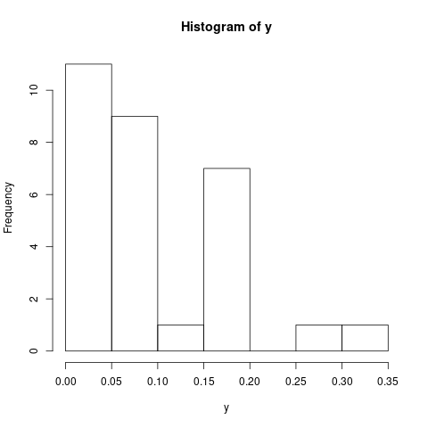

```python
%%R -o n -o y

set.seed(1234)
th2 <- 10
n <- 30.0
y <- rexp(n,th2)
hist(y)
```

- Los estadísticos observados son:

```python
%%R -o sumy -o ybar -o sumlny

sumy <- sum(y)
ybar <- sumy/n
sumlny <- sum(log(y))
```

La estimación de $\theta_1$ se obtiene numéricamente en R

```
[1] 0.8020572 8.5462460
```

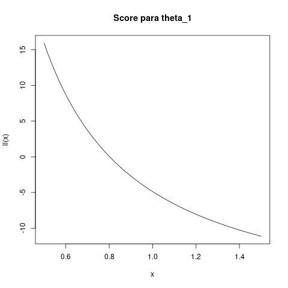

```python
%%R -o th1hat -o th2hat
ll <- function(x)sumlny-n*digamma(x)+n*log(x)-n*log(ybar)
curve(ll,0.5,1.5, main="Score para theta_1")
th1hat <- uniroot(ll,c(0.5,1.5))$root
th2hat <- th1hat/ybar
# Estimaciones de theta-1 y theta_2
(thhat <- c(th1hat,th2hat))
```

- Estimación de la matriz de covarianza asintótica

```python
%%R -o Sigmahat
Sigma <- function(th1,th2) matrix(c(th1,th2,th2,th2^2*trigamma(th1)),nrow=2)/(n*(th1*trigamma(th1)-1))
Sigmahat <- Sigma(th1hat,th2hat)
Sigmahat
```

```
           [,1]      [,2]
[1,] 0.03194074 0.3403416
[2,] 0.34034165 6.6619368
```

- Intervalos de confianza al 95%

```python
%%R -o CI95
CI95 <- thhat+matrix(1.96*sqrt(diag(Sigmahat))%x%c(-1,1),nrow=2,byrow=T)
CI95
```

```
          [,1]      [,2]
[1,] 0.4517665  1.152348
[2,] 3.4873433 13.605149
```

- Los intervalos de confianza para $\theta_1$ y $\theta_2 $ contienen los valores verdaderos $\theta_1=1$ y $\theta_2=10$

## Distribución *a posteriori* conjunta

La distribución *a posteriori* conjunta es proporcional al producto de la función de verosimilitud y la distribución *a priori* conjunta. No es necesario que $y_1,\ldots,y_n$ sea una muestra aleatoria (*iid*).

\begin{eqnarray} \pi(\boldsymbol{\theta}\mid \mathbf{y})&\propto&\pi(\boldsymbol{\theta})L(\boldsymbol{\theta}\mid \mathbf{y})\\ &\propto& \pi(\boldsymbol{\theta})\exp\left\{t^{\prime}(\mathbf{y})\boldsymbol{\theta}-nb(\boldsymbol{\theta})\right\}\\ &\propto&\theta_1^{a-1}\exp(-b\theta_1)\theta_2^{c-1}\exp(-d\theta_2)\exp\left\{t^{\prime}(\mathbf{y})\boldsymbol{\theta}-nb(\boldsymbol{\theta})\right\}\\ &=&\theta_1^{a-1}\exp(-b\theta_1)\theta_2^{c-1}\exp(-d\theta_2)\exp\left\{\theta_1\sum_{i=1}^n \ln y_i-\theta_2\sum_{i=1}^n y_i+n\ln\left(\frac{\theta_2^{\theta_1}}{\Gamma(\theta_1)}\right)\right\} \end{eqnarray}

Por definición, la distribución marginal para un parámetro de interés se obtiene integrando la conjunta con respecto a los parámetros de ruido. En este ejemplo, \begin{eqnarray} \pi(\theta_1\mid\mathbf{y})&=&\int_{0}^\infty\pi(\boldsymbol{\theta}\mid \mathbf{y})\mathrm{d}\theta_2\\ &\propto&\theta_1^{a-1}\exp(-b\theta_1)\exp\left\{\theta_1\sum_{i=1}^n \ln y_i-n\ln\left(\Gamma(\theta_1)\right)\right\}\int_{0}^\infty\theta_2^{c-1}\exp(-d\theta_2)\exp\left\{-\theta_2\sum_{i=1}^n y_i+n\ln\left(\theta_2^{\theta_1}\right)\right\}\\ &=&\frac{1}{\Gamma(\theta_1)^n}\theta_1^{a-1}\exp\left\{\theta_1\left(\sum_{i=1}^n\ln y_i-b\right)\right\} \int_{0}^\infty\theta_2^{n\theta_1+c-1}\exp\left\{-\theta_2\left(\sum_{i=1}^n y_i+d\right)\right\}\mathrm{d}\theta_2\\ &&\text{Completando una densidad gamma en el integrando}\\ &\propto&\frac{\Gamma(n\theta_1+c)}{\Gamma(\theta_1)^n}\frac{\theta_1^{a-1}}{\left(\sum_{i=1}^n y_i+d\right)^{n\theta_1+c}}\exp\left\{\theta_1\left(\sum_{i=1}^n \ln y_i-b\right)\right\} \end{eqnarray}

En algunos casos es posible obtener la distribución marginal del parámetro de interés a partir de las distribuciones conjunta y condicional del parámetro de ruido si se conoce la constante de normalización de la segunda, ya que esta puede depender del parámetro de interés. La distribución condicional *a posteriori* de $\theta_2$ dado $\theta_1$ se obtiene a partir de la expresión anterior manteniendo fijo $\theta_1$. Así,

$$ \pi(\theta_2\mid\theta_1,\mathbf{y})\propto \theta_2^{n\theta_1+c-1}\exp\left\{-\left(\sum_{i=1}^n y_i+d\right)\theta_2\right\}. $$

Por lo tanto, $\theta_2\mid\theta_1,\mathbf{y}\sim \mathrm{Ga}\left(n\theta_1+c,\sum_{i=1}^n y_i+d\right)$. Nótese que la constante de normalización de la función de densidad condicional de $\theta_2$ depende de $\theta_1$ a través del parámetro de forma. Por definición,

$$ \pi(\theta_2\mid\theta_1,\mathbf{y})=\frac{\pi(\boldsymbol{\theta}\mid \mathbf{y})}{\pi(\theta_1\mid\mathbf{y})}, $$

de donde se sigue que

\begin{eqnarray} \pi(\theta_1\mid\mathbf{y})&=&\frac{\pi(\boldsymbol{\theta}\mid \mathbf{y})}{\pi(\theta_2\mid\theta_1,\mathbf{y})},\quad\forall \theta_2\in\Theta_2\\ &\propto &\frac{\theta_1^{a-1}\exp(-b\theta_1)\theta_2^{c-1}\exp(-d\theta_2) \exp\left\{\theta_1\sum_{i=1}^n \ln y_i-\theta_2\sum_{i=1}^n y_i+n\ln\left(\frac{\theta_2^{\theta_1}}{\Gamma(\theta_1)}\right)\right\}}{\frac{\left(\sum_{i=1}^n y_i+d\right)^{n\theta_1+c}}{\Gamma(n\theta_1+c)}\theta_2^{n\theta_1+c-1}\exp\left\{-\theta_2\left(\sum_{i=1}^n y_i+d\right)\right\}}\\ &\propto&\frac{\theta_1^{a-1}\exp(-b\theta_1) \exp\left\{\theta_1\sum_{i=1}^n \ln y_i+n\ln\left(\frac{1}{\Gamma(\theta_1)}\right)\right\}}{\frac{\left(\sum_{i=1}^n y_i+d\right)^{n\theta_1}}{\Gamma(n\theta_1+c)}}\\ &\propto& \frac{\Gamma(n\theta_1+c)}{\Gamma(\theta_1)^n}\frac{\theta_1^{a-1}}{\left(\sum_{i=1}^n y_i+d\right)^{n\theta_1}}\exp\left\{\theta_1\left(\sum_{i=1}^n \ln y_i-b\right)\right\} \end{eqnarray}

Este resultado es igual al que se obtiene por integración directa de la conjunta, excepto por una constante de proporcionalidad. En lo que sigue se toman los hiperparámetros $a=b=c=d=0.0001$, de modo que las distribuciones *a priori* son planas pero propias.

- Densidad marginal a posteriori de $\theta_1$ no normalizada

```python
n=float(n)
sumy=float(sumy)
sumlny=float(sumlny)

var('a b c d')
fth1(x)=gamma(n*x+c)/gamma(x)^n*x^(a-1)/(sumy+d)^(n*x)*exp(x*(sumlny-b))
```

```python
fth1(1).subs(a=0.0001,b=0.0001,c=0.0001,d=0.0001)
```

```
9.89352185223406e-24
```

- Cálculo de la constante de normalización

```python
cte=numerical_integral(fth1(x).subs(a=0.0001,b=0.0001,c=0.0001,d=0.0001),0,3)[0]
fth1(x)=fth1(x)/cte
cte
```

```
1.0586787692115499e-23
```

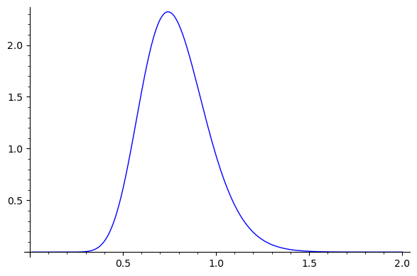

```python
plot(fth1(x).subs(a=0.0001,b=0.0001,c=0.0001,d=0.0001),x,0,2)
```

```python
numerical_integral(fth1(x).subs(a=0.0001,b=0.0001,c=0.0001,d=0.0001),0,3)[0]
```

```
1.0
```

El estimador bayesiano MAP (*maximum a posteriori probability*) es la moda de la distribución *a posteriori*; esto es, $$ \hat\theta_{MAP}=\mathrm{max\,arg} f(\theta\mid x) $$

```python
lfth1(x)=-log(fth1(x).subs(a=0.0001,b=0.0001,c=0.0001,d=0.0001))
plot(lfth1(x),x,0,2)
thmap=find_local_minimum(lfth1,0.5,1)[1]
thmap
```

```
0.7426080372080671
```

- En inferencia bayesiana un intervalo creible al $(1-\alpha)100\%$ es aquel contiene el valor verdadero del parámetro con probabilidad *a posteriori* $1-\alpha$.

[figure not shown]

```python
var('t')
Fth1= lambda x:numerical_integral(fth1(t).subs(a=0.0001,b=0.0001,c=0.0001,d=0.0001),0,x)[0]
Fth1(0.5)
q025=find_root(lambda x:Fth1(x)-0.025,0,1)
q975=find_root(lambda x:Fth1(x)-0.975,1,2)
print(q025,q975)
```

```
0.48232635637190263 1.170950342542256
```

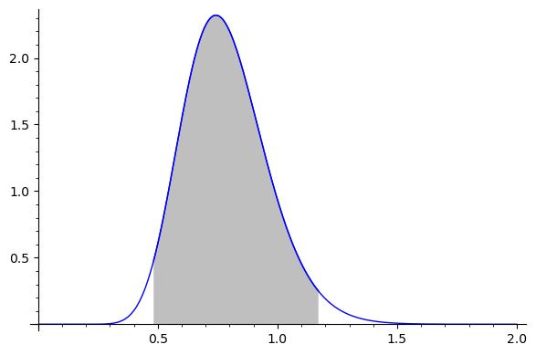

```python
plot(fth1(x).subs(a=0.0001,b=0.0001,c=0.0001,d=0.0001),x,0,2)+plot(fth1(x).subs(a=0.0001,b=0.0001,c=0.0001,d=0.0001),x,q025,q975,fill=True)
```

- Un intervalo HPD (Highest Posterior Density) es el intervalo de longitud mínima que contiene los valores del parámetro con mayor densidad.

[figure not shown]

```python
var('h')
fmode=fth1(thmap).subs(a=0.0001,b=0.0001,c=0.0001,d=0.0001)
clim(x,h)=fth1(x).subs(a=0.0001,b=0.0001,c=0.0001,d=0.0001)/fmode-h
ll=find_root(clim(x,0.145),max(0,CI95[0,0]-1),th1hat[0])
ul=find_root(clim(x,0.145),th1hat[0],CI95[0,1]+1)
numerical_integral(fth1(x).subs(a=0.0001,b=0.0001,c=0.0001,d=0.0001),ll,ul)[0]
print(ll,ul)
```

```
0.45969554528841555 1.1364095830977692
```

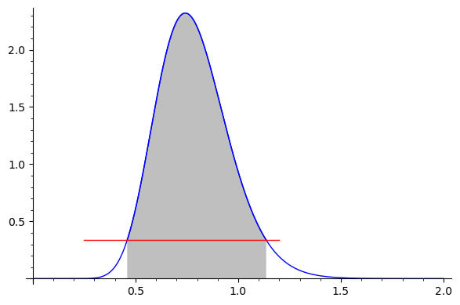

```python
plot(fth1(x).subs(a=0.0001,b=0.0001,c=0.0001,d=0.0001),x,0,2)+plot(fth1(x).subs(a=0.0001,b=0.0001,c=0.0001,d=0.0001),x,ll,ul,fill=True)+plot(0.145*fmode,x,0.25,1.2,color="red")
```

- Comparación de la distribución *a posteriori* con su aproximación asintótica (normal)

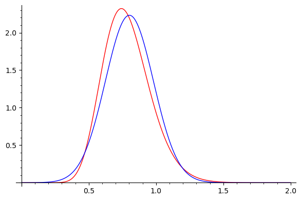

```python
var('mu sigma')
f(x)=1/sqrt(2*pi*sigma^2)*exp(-(x-mu)^2/(2*sigma^2))

plot(fth1(x).subs(a=0.0001,b=0.0001,c=0.0001,d=0.0001),x,0,2,color="red")+plot(f(x).subs(mu=th1hat[0],sigma=sqrt(Sigmahat[0,0])),x,0,2)
```

- Se puede observar que la aproximación normal es similar a la distribución exacta aun con tamaño de muestra $n=30$. Cuando $n\to\infty$ la distribución a posteriori converge a una normal (TCL bayesiano).
- Es común que la distribución marginal *a posteriori* no tenga forma cerrada o que este definida en términos de integrales complejas y/o en grandes dimensiones, lo que complica la aproximación numérica. En tales casos se puenden utilizar métodos de simulación (Monte Carlo) para generar muestras (no neceariamente independientes) de la distribución *a posteriori*. Con una muestra de tamaño arbitrario se pueden estimar cantidades de interés de la distribución *a postetiori* (media, moda, varianza, intervalos creibles, etc.). El estimador bayesiano bajo pérdida cuadrática está dado por la esperanza $$ \mathrm{E}\left(\theta\mid x\right)=\int_{\Theta}\theta f(\theta\mid x)\mathrm{d}\theta $$ y puede calcularse por medio de integración Monte Carlo como $$ \hat{\mathrm{E}}\left(\theta\mid x\right)=\frac{1}{s}\sum_{i=1}^s\theta^{(i)} $$ donde $\theta^{(i)}, i=1,\ldots,s$ es una muestra de $f(\theta\mid x)$. Del mismo modo, $$ \Pr\left(\theta\in C\mid x\right)\approx\frac{1}{s}\sum_{i=1}^sI\left(\theta^{(i)}\in C\right) $$

Un método de generación de números aleatorias es el de Aceptación-Rechazo. Con este método se pueden simular muestras de distribuciones aunque no se conozca la constante de proporcionalidad. Se utiliza la densidad $g$ de una distrinución generadora de candidatos, que al ser multiplicada por una constante $M$ cubre a la densidad objetivo $f$ en todo su soporte. La probabilidad de aceptar un valor candidato es $1/M$, por lo que M debe ser pequeña; dado que $f(x)\leq Mg(x)$, el valor óptimo de M es $\mathrm{sup}f(x)/g(x)$. En el ejemplo, se puede utilizar el hecho de que $$ \pi(\theta_2,\theta_1\mid \mathbf{y})=\pi(\theta_2\mid\theta_1, \mathbf{y})\pi(\theta_1\mid \mathbf{y}), $$

donde $(\theta_2\mid\theta_1, \mathbf{y})$ es una gamma, de la que es fácil simular directamente, y puede utilizarse Aceptación-Rechazo para simular de $\pi(\theta_1\mid \mathbf{y})$. Esto es,

Para $i$ de $1$ a $s$:

$\quad\quad\theta_1^{(i)}\leftarrow\sim \pi(\theta_1\mid \mathbf{y})\quad$ Aceptación-Rechazo

$\quad\quad\theta_2^{(i)}\leftarrow\sim \pi(\theta_2\mid\theta_1^{(i)}, \mathbf{y})\quad$ Simulación directa

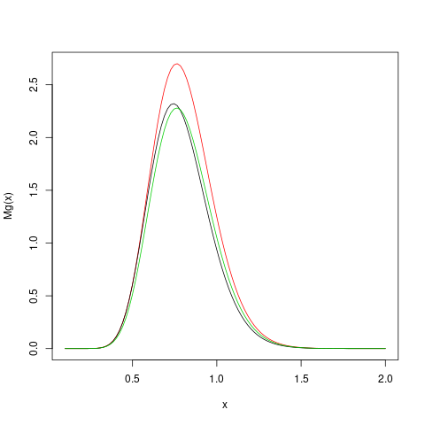

```python
%%R -i cte
objf <- function(x)gamma(n*x+c)/gamma(x)^n*x^(a-1)/(sumy+d)^(n*x)*exp(x*(sumlny-b))/cte
propg <- function(x)dgamma(x,th1hat^2/Sigmahat[1,1],th1hat/Sigmahat[1,1])
rpropg <- function()rgamma(1,th1hat^2/Sigmahat[1,1],th1hat/Sigmahat[1,1])
a=0.0001;b=0.0001;c=0.0001;d=0.0001
dif2 <- function(x) -objf(x)/propg(x)
M <- -nlm(dif2,1)$minimum
Mg <- function(x)propg(x)*M
curve(Mg,0.1,2,col=2)
curve(objf,0.1,2,add=T)
curve(propg,0.1,2,add=T,col=3)
th1sample <- NULL
th2sample <- NULL
s <- 1000
i <-0
while(i<s){
    xnew <- rpropg()
    u <- runif(1)
    if(Mg(xnew)*u <= objf(xnew)){
        th1sample <- c(th1sample,xnew)
        th2sample <- c(th2sample,rgamma(1,n*xnew+c,sumy+d))
        i <- i+1
    }
}
```

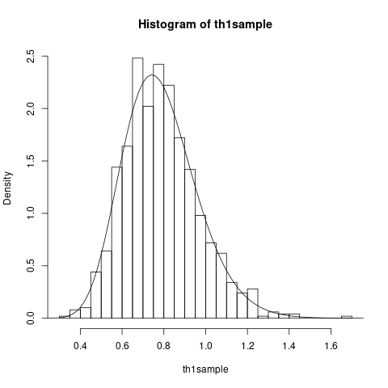

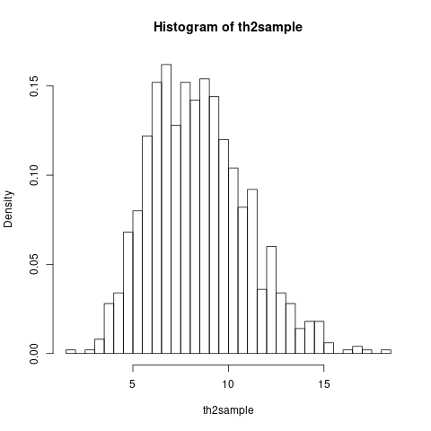

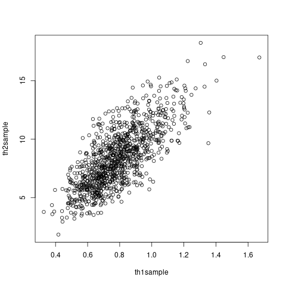

```python
%%R
hist(th1sample,breaks=30,freq=F)
curve(objf,0,2,add=T)
hist(th2sample,breaks=30,freq=F)
plot(th1sample,th2sample)
```

```python
%%R
summary(coda::as.mcmc(th1sample))
```

```
Iterations = 1:1000
Thinning interval = 1
Number of chains = 1
Sample size per chain = 1000

1. Empirical mean and standard deviation for each variable,
   plus standard error of the mean:

          Mean             SD       Naive SE Time-series SE
        0.7883         0.1771         0.0056         0.0056

2. Quantiles for each variable:

  2.5%    25%    50%    75%  97.5%
0.4919 0.6653 0.7700 0.8940 1.1887
```

```python
%%R
summary(coda::as.mcmc(th2sample))
```

```
Iterations = 1:1000
Thinning interval = 1
Number of chains = 1
Sample size per chain = 1000

1. Empirical mean and standard deviation for each variable,
   plus standard error of the mean:

          Mean             SD       Naive SE Time-series SE
       8.40548        2.52852        0.07996        0.07996

2. Quantiles for each variable:

  2.5%    25%    50%    75%  97.5%
 4.229  6.524  8.210 10.007 14.129
```

```python
%%R
coda::HPDinterval(coda::as.mcmc(th1sample))
```

```
         lower    upper
var1 0.4767543 1.140384
attr(,"Probability")
[1] 0.95
```

```python
%%R
coda::HPDinterval(coda::as.mcmc(th2sample))
```

```
        lower    upper
var1 3.630512 13.15859
attr(,"Probability")
[1] 0.95
```